# assignment

## Different People Have Different Sources of Happiness

Different people derive their happiness from different sources. By investigating these sources, we can fundamentally understand the key to enhancing happiness. We are fortunate to have access to the HappyDB database, which contains a wealth of workers’ descriptions of their sources of happiness. By examining this dataset and identifying the diverse sources of happiness, we can assist factories in devising targeted incentive plans to boost happiness and, consequently, productivity. In this notebook, we employ R notebook for data mining and ultimately display the various sources of happiness for different people via word clouds.

### Step 0 - Load all the required libraries

```r
library(dplyr)
library(ggplot2)
library(reshape2)
library(stringr)
library(wordcloud2)
library(shiny)
library(htmlwidgets)
library(webshot)
library(png)
library(grid)
#webshot::install_phantomjs()
source('../lib/wordcloud.R')
```

### Step 1 - Load the data from HappyDB and Data preprocessing

Dataset using: HappyDB, HappyDB is a corpus of 100,000+ crowd-sourced happy moments. The goal of the corpus is to advance the state of the art of understanding the causes of happiness that can be gleaned from text.

```r
cleaned_hm <- read.csv("../data/cleaned_hm.csv")
demographics <- read.csv("../data/demographic.csv")
```

Combine both the datasets and keep only the required columns

```r
merged_data <- merge(cleaned_hm, demographics, by = "wid", all.y = TRUE)
selected_data <- merged_data[, c("wid", "hmid", "predicted_category", "age", "country", "gender", "marital", "parenthood")]
```

Data preprocessing Clean the NA values:

```r
prev_na <- sapply(selected_data, function(y) sum(length(which(is.na(y)))))
print("NA Values:")
```

```
## [1] "NA Values:"
```

```r
print(prev_na[prev_na > 0])
```

```
##               hmid predicted_category
##                  3                  3
```

```r
selected_data <- na.omit(selected_data)
```

We now have a dataset devoid of any empty values. The next step is to remove non-majority categories from the dataset. This is not because these categories are unimportant, but because their numbers are too small to be representative.

```r
selected_data <- subset(selected_data, gender == "f" | gender == "m")
selected_data <- subset(selected_data, parenthood == "n" | parenthood == "y")
selected_data$marital <- ifelse(selected_data$marital == "married", "married", "not-married")
selected_data$age <- as.numeric(selected_data$age)
selected_data <- subset(selected_data, age >= 18 & age <= 100)
```

### Step 2 - Data Exploration:

At this stage, we will explore the data, identify its unique characteristics, and analyze its median. The code below will generate the number of data entries from workers in different countries. The chart reveals that the data from USA workers greatly exceeds the total from other countries, suggesting that our analysis might not be representative of other nations, nor can it explore the differences between them. Therefore, this analysis will focus solely on data from American workers.

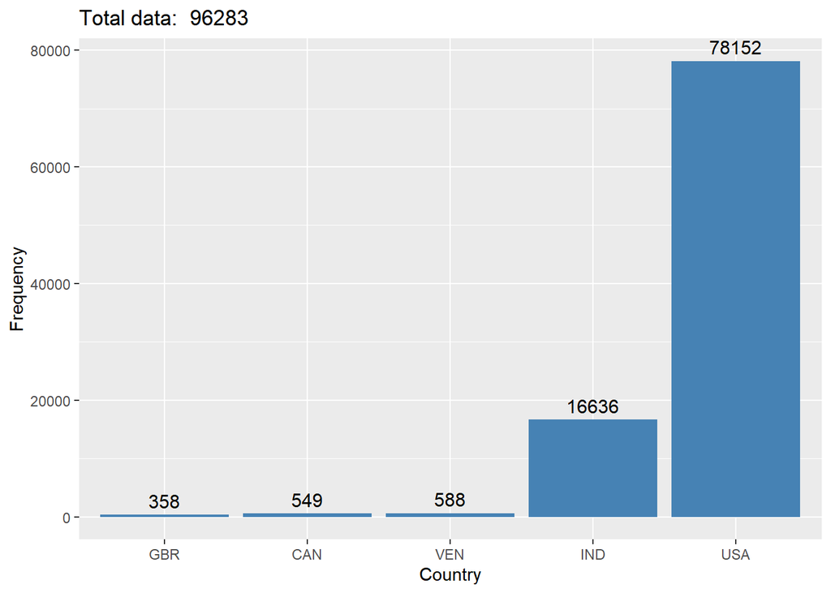

```r
top_countries <- selected_data %>%
  count(country) %>%
  arrange(desc(n)) %>%
  head(5)

ggplot(top_countries, aes(x=reorder(country, n), y=n)) +
  geom_bar(stat="identity", fill="steelblue") +
  geom_text(aes(label=n), vjust=-0.5, size=4) +
  labs(x="Country", y="Frequency",title = paste("Total data: ", sum(top_countries$n)))
```

```r
selected_data <- subset(selected_data, country == "USA")
```

Here, we have produced five charts. The first three represent the proportion of data pertaining to different genders, marital statuses, and parenthood statuses. The fourth chart represents the tags of the workers’ sources of happiness. From the chart, we can see that most people find happiness in Affection and Achievement. However, these tags are not detailed enough to analyze workers’ sources of happiness, so we need to rely on their specific sentences for further analysis. The fifth chart displays the age distribution of the surveyed workers. From this age chart, we can see that the majority of ages range from 20 (actually 18) to 60, so we will limit our subsequent analysis to this age range.

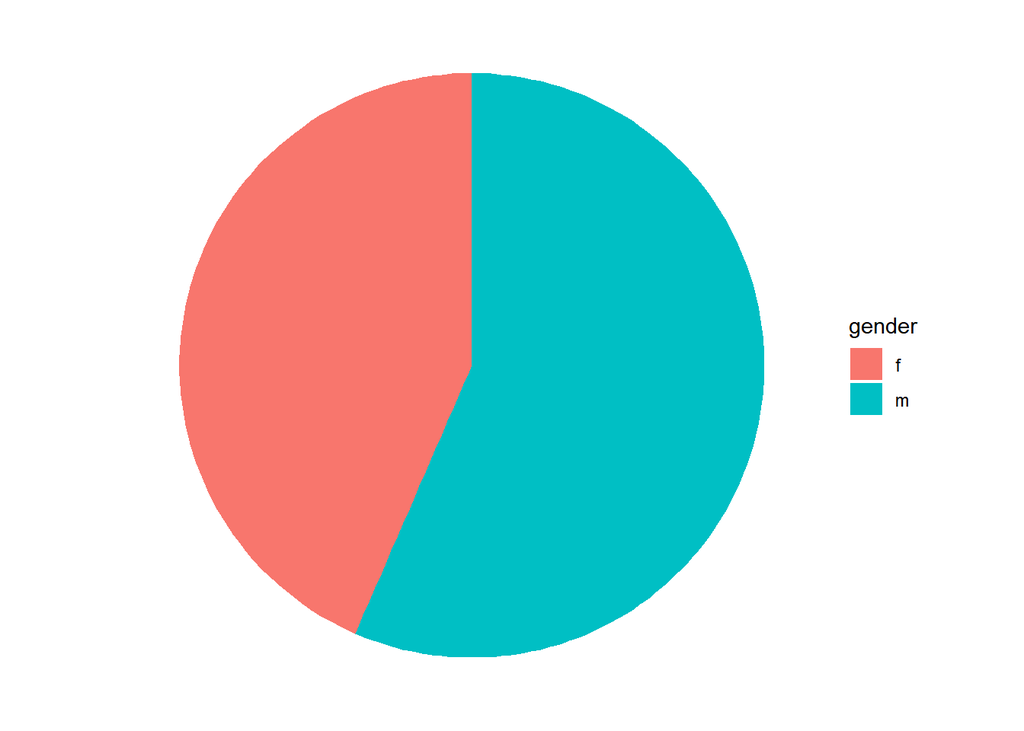

```r
ggplot(selected_data, aes(x="", fill=gender)) +
  geom_bar(width = 1) +
  coord_polar("y", start=0) +
  theme_void()
```

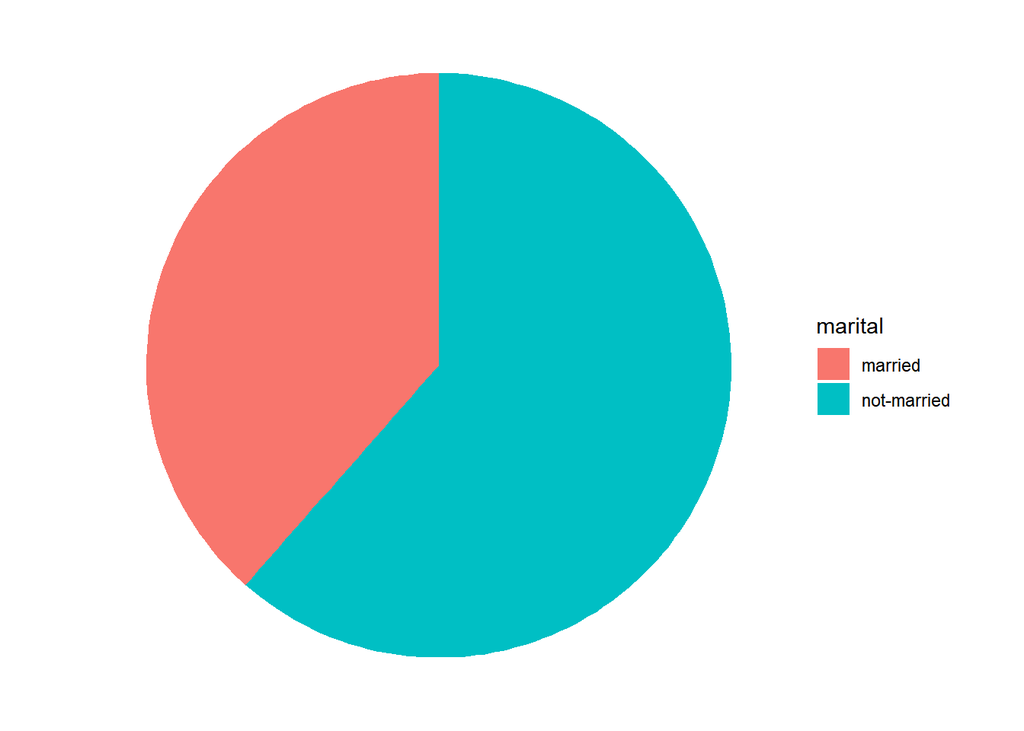

```r
ggplot(selected_data, aes(x="", fill=marital)) +
  geom_bar(width = 1) +
  coord_polar("y", start=0) +
  theme_void()
```

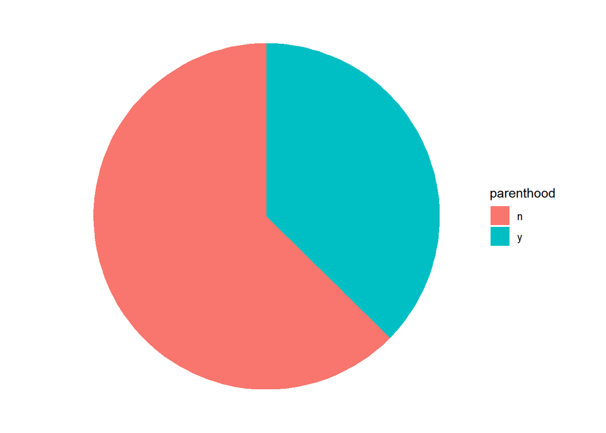

```r
ggplot(selected_data, aes(x="", fill=parenthood)) +
  geom_bar(width = 1) +
  coord_polar("y", start=0) +
  theme_void()
```

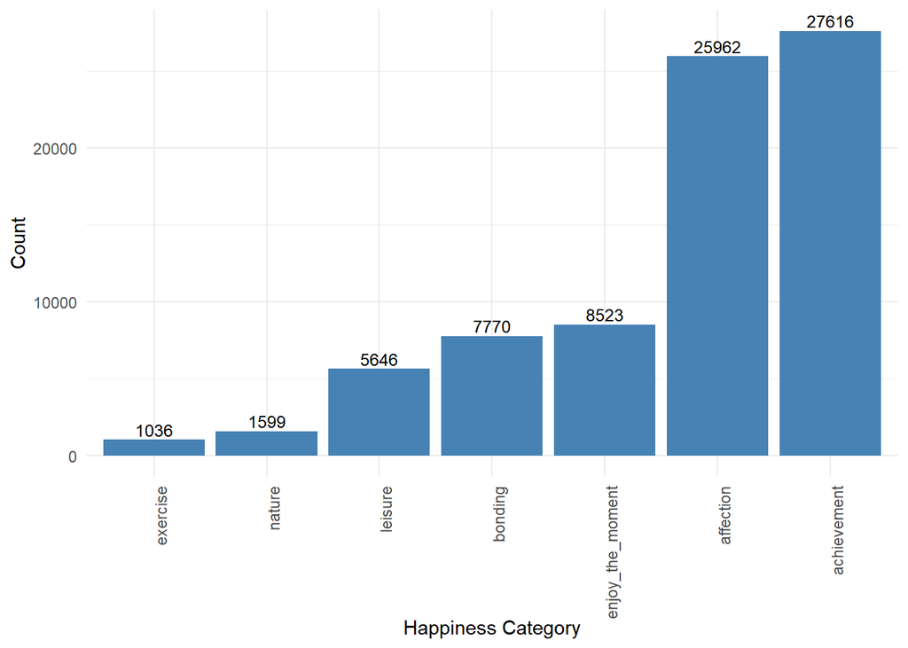

```r
category <- selected_data %>%
  count(predicted_category) %>%
  arrange(desc(n))
ggplot(category, aes(x=reorder(predicted_category, n), y=n)) +
  geom_bar(stat="identity", fill="steelblue") +
  geom_text(aes(label=n), vjust=-0.3, size=3.3) +
  labs(x="Happiness Category", y="Count") +
  theme_minimal() +
  theme(axis.text.x = element_text(angle = 90, hjust = 1))
```

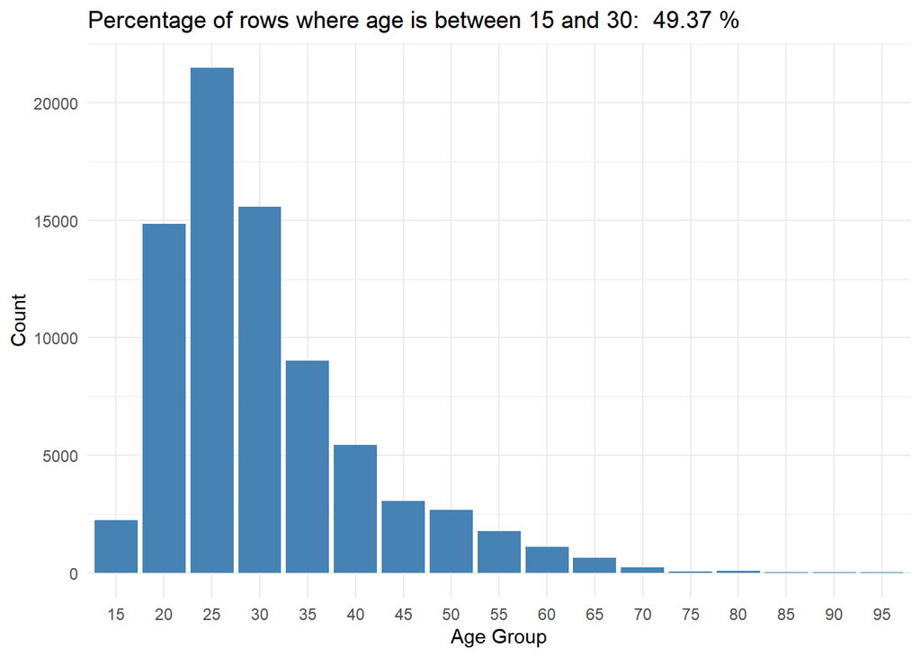

```r
selected_data$age <- as.numeric(selected_data$age)
selected_data <- selected_data %>% filter(age >= 1 & age <= 100)
selected_data$age_group <- cut(selected_data$age, breaks = seq(0, 100, by = 5))
levels(selected_data$age_group) <- seq(0, 95, by = 5)
ggplot(selected_data, aes(x=age_group)) +
  geom_bar(fill = "steelblue") +
  labs(x="Age Group", y="Count",title = paste("Percentage of rows where age is between 15 and 30: ", round(selected_data%>% filter(age >= 18, age <= 30) %>% nrow() / nrow(selected_data) * 100, 2), "%"))+
  theme_minimal()
```

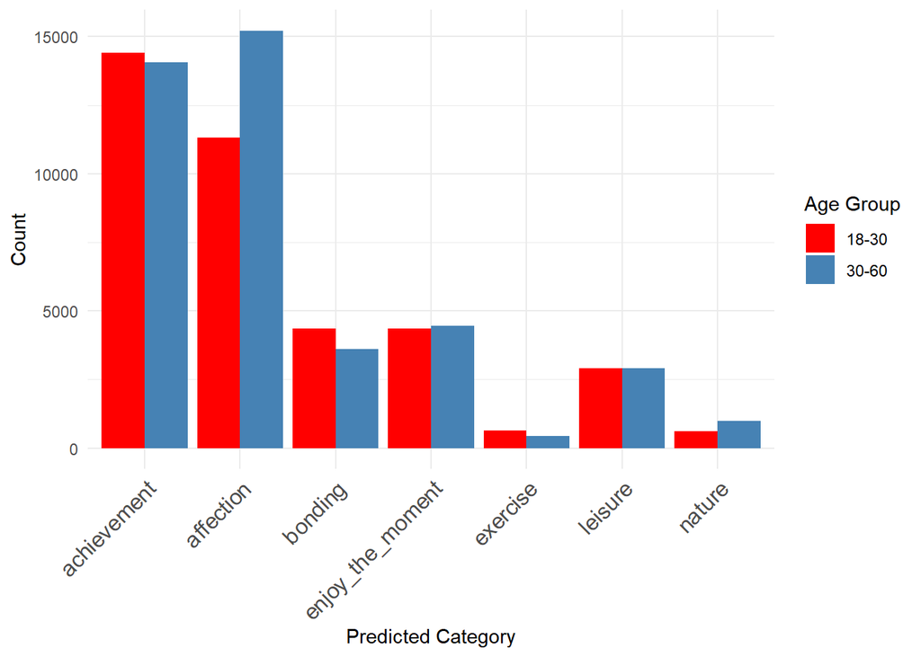

```r
teen = selected_data%>% filter(age >= 18, age <= 30)
mid  = selected_data%>% filter(age >= 30, age <= 60)
teen$age_group <- "18-30"
mid$age_group <- "30-60"
df <- rbind(teen, mid)
df <- df %>%
  group_by(age_group, predicted_category) %>%
  summarise(count = n())
ggplot(df, aes(x=predicted_category, y=count, fill=age_group)) +
  geom_bar(stat="identity", position="dodge") +
  scale_fill_manual(values=c("18-30"="red", "30-60"="steelblue")) +
  theme_minimal() +
  labs(x="Predicted Category", y="Count", fill="Age Group") +
  theme(axis.text.x = element_text(angle = 45, hjust = 1, size=12))
```

### Step 4 - Word Cloud

To further explore the different sources of happiness for people with different tags, we extract the sentence components from the ‘senselabel’ data table when they answer the question. We extract nouns to help us analyze, as nouns are more concrete than verbs and other sentence components, making them easier for us to understand and less abstract.

```r
cleaned_hm <- read.csv("../data/cleaned_hm.csv")
demographics <- read.csv("../data/demographic.csv")
label <- read.csv("../data/senselabel.csv")
```

```r
label_data <- label %>%
  filter(str_starts(POS, "NOUN")) %>%
  select(hmid, lowercaseLemma, POS, supersenseLabel)

label_merged <- merge(label_data, cleaned_hm, by = "hmid", all.x = TRUE)%>%
  select(hmid, wid, lowercaseLemma, supersenseLabel)
label_merged <- merge(label_merged, demographics, by = "wid", all.x = TRUE)%>%
  filter(age >= 18 & age <= 60)%>%
  filter(country=='USA')%>%
  filter(supersenseLabel != "")%>%
  mutate(lowercaseLemma = str_replace_all(lowercaseLemma, "[^[:alpha:]]", "")) %>%
  filter(lowercaseLemma != "") %>%
  select(hmid, wid, lowercaseLemma, supersenseLabel, age, gender, marital, parenthood)

label_merged$age <- as.numeric(label_merged$age)
label_merged <- label_merged %>%
  mutate(age_group = case_when(
    age >= 18 & age <= 30 ~ "18-30",
    age > 30 & age <= 60 ~ "30-60",
  ))
head(label_merged, 20)
```

```
##      hmid wid lowercaseLemma supersenseLabel age gender marital parenthood
## 1   40519   1            day          n.time  37      m married          y
## 2   30850   1            son        n.person  37      m married          y
## 3   44650   1           wife        n.person  37      m married          y
## 4  102475   1            day          n.time  37      m married          y
## 5   79306   1          price    n.possession  37      m married          y
## 6   79306   1         change     n.cognition  37      m married          y
## 7   42394   1           time          n.time  37      m married          y
## 8   95597   1          movie n.communication  37      m married          y
## 9   79306   1          stock    n.possession  37      m married          y
## 10  44650   1        morning          n.time  37      m married          y
## 11  47392   1            mom        n.person  37      m married          y
## 12 128553   1         mother        n.person  37      m married          y
## 13  91592   1            day          n.time  37      m married          y
## 14  48987   1    motherinlaw        n.person  37      m married          y
```

[output cut: 27 more lines]

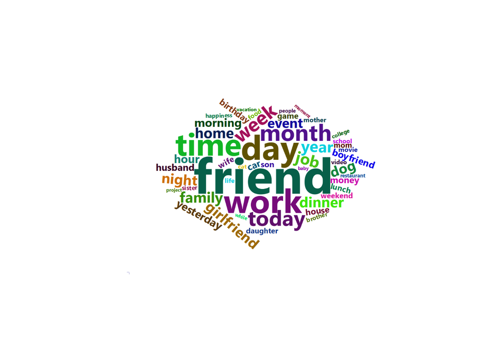

```r
word_counts <- label_merged %>%
  group_by(age_group, lowercaseLemma) %>%
  summarise(count = n()) %>%
  arrange(desc(count))%>%
  select(word = lowercaseLemma, freq = count)

word_counts_teen <- word_counts %>%
  ungroup() %>%
  filter(age_group == "18-30")%>%
  select(word, freq)%>%
  head(50)
word_counts_mid <- word_counts %>%
  ungroup() %>%
  filter(age_group == "30-60")%>%
  select(word, freq)%>%
  head(50)
w1 = wordcloud2(word_counts_teen)
saveWidget(w1, "../figs/temp1.html", selfcontained = F)
w2 = wordcloud2(word_counts_mid, color='random-dark')
saveWidget(w2, "../figs/temp2.html", selfcontained = F)

if (file.exists("../figs/age_group_teen.png")) {
  img <- readPNG("../figs/age_group_teen.png")
  draw_image(img)
}else{
  webshot("../figs/temp1.html", "../figs/age_group_teen.png", delay = 20)
  img <- readPNG("../figs/age_group_teen.png")
  draw_image(img)
}
```

[figure not shown]

```r
if (file.exists("../figs/age_group_mid.png")) {
  img <- readPNG("../figs/age_group_mid.png")
  draw_image(img)
}else{
  webshot("../figs/temp1.html", "../figs/age_group_mid.png", delay = 20)
  img <- readPNG("../figs/age_group_mid.png")
  draw_image(img)
}
```

The first of this pair of word clouds is about the happiness of married people, and the second is for unmarried people. Aside from their common points and some meaningless words, it can be seen that married people derive more happiness from work, family, and family members, and events like birthdays. Unmarried people, on the other hand, care more about friends, games, food, boyfriends and girlfriends, and some entertainment activities like movies.

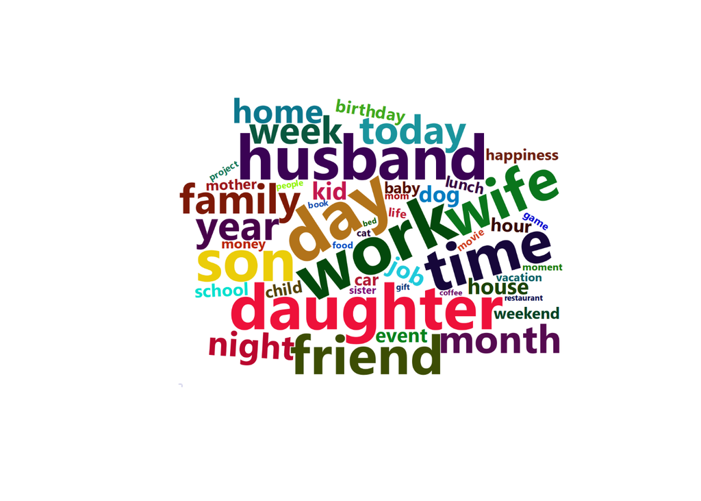

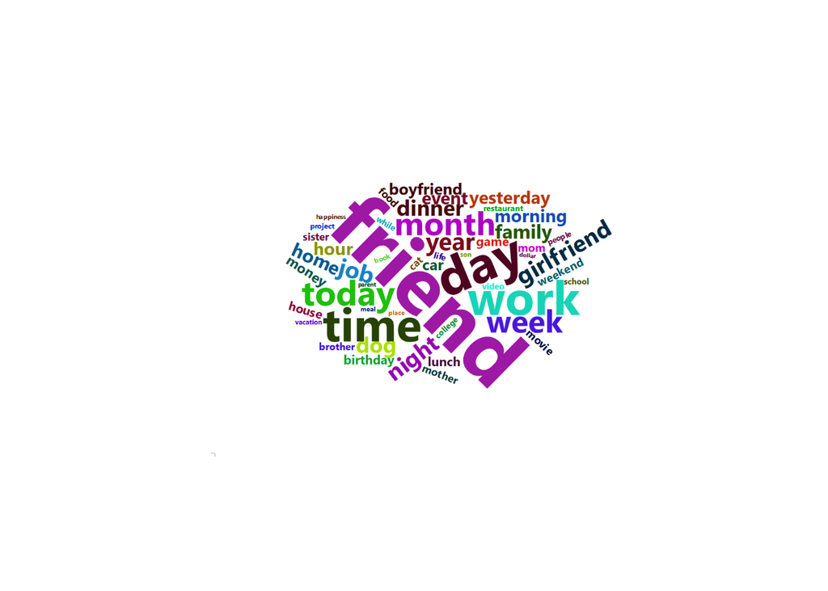

```r
# Married vs. Single
generate_wordclouds("marital")
```

The first of this pair of word clouds is about the happiness of people with parenthood, and the second is for people without parenthood. The results here are basically consistent with those of married and unmarried people.

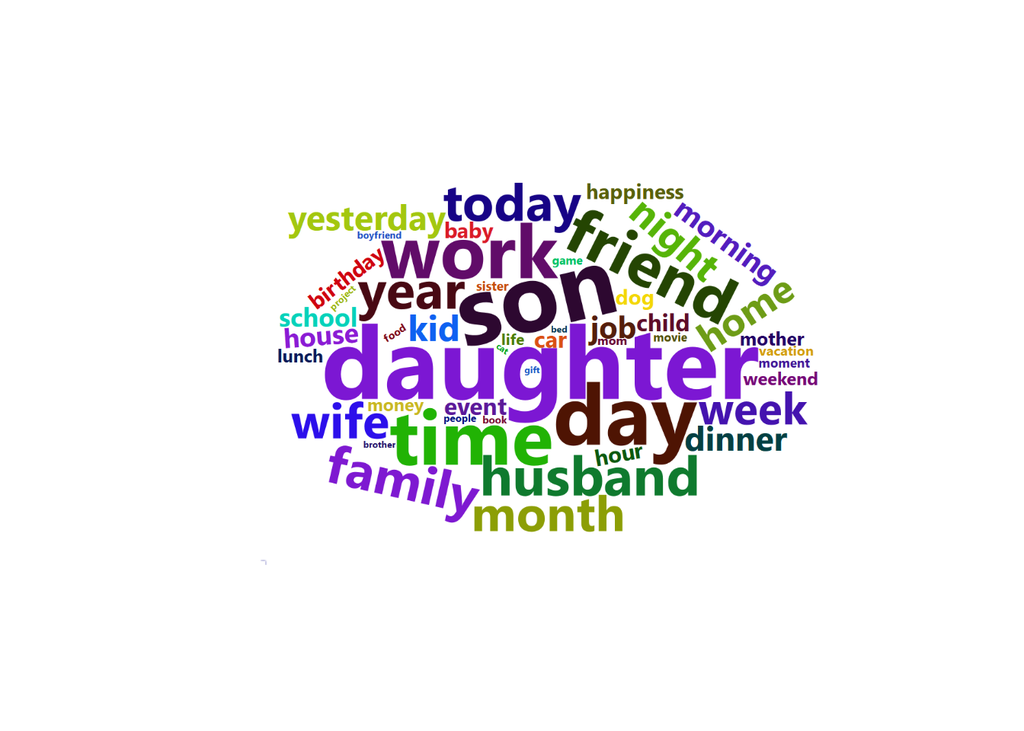

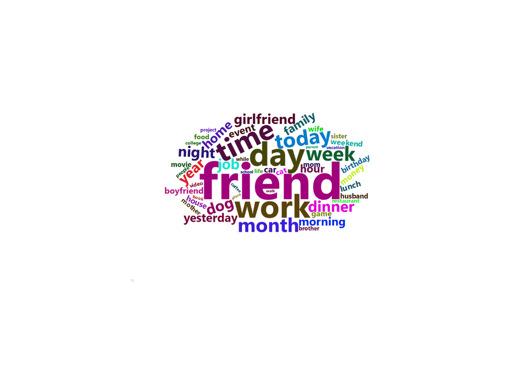

```r
generate_wordclouds("parenthood")
```

The first of this pair of word clouds is about the happiness of men, and the second is for women. In comparison, women mention happiness from children more frequently, while men mention it less. Men often mention games, pets, money, and some entertainment activities.

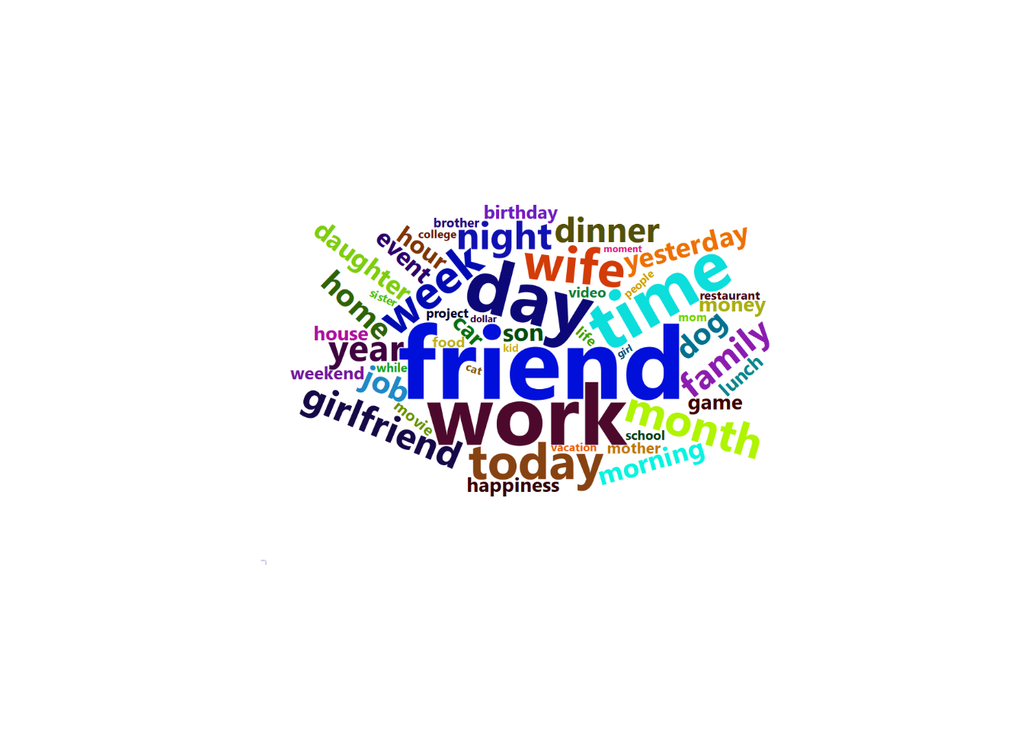

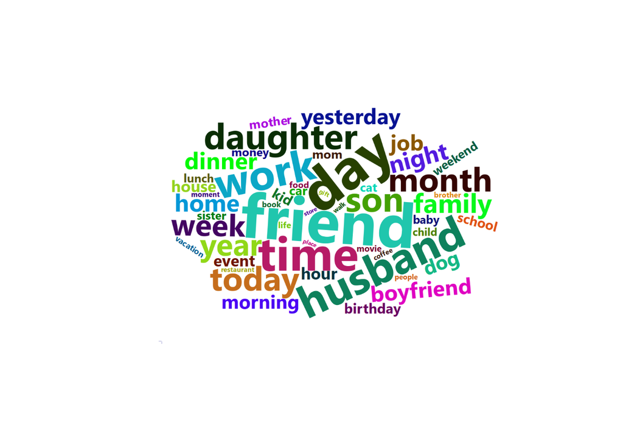

```r
generate_wordclouds("gender")
```

### Summary

This analysis, based on the HappyDB database, reveals that people’s sources of happiness vary significantly based on their demographic characteristics such as age, marital status, parenthood status, and gender. The study uses data mining techniques and visualizes the results through word clouds, providing a unique perspective on what makes different groups of people happy. This information can be extremely valuable for organizations looking to boost happiness and productivity among their workers.